# Homework 13

Nick Climaco

2023-11-27

# Exercise 1

Use integration by substitution below
$$\int 4 e^{-7x} dx$$

## Solution

$$\text{Let u = -7x}, \text{and then} \ -\frac{1}{7} du = dx \\
\int 4 e^{7x} dx \Rightarrow 4 \int e^u du \\
\Rightarrow -\frac{4}{7} e^{-7x} + C$$

# Exercise 2

Biologists are treating a pond contaminated with bacteria. The level of contamination is changing at a rate of $\frac{dN}{dt} = -\frac{3150}{t^4} - 220$ bacteria per cubic centimeter per day, where t is the number of days since treatment began. Find a function N(t) to estimate the level of contamination if the level after 1 day was 6530 bacteria per cubic centimeter.

## Solution

$$\int \frac{d}{dt}N = \int -\frac{3150}{t^4} - 220 dt \\
\Rightarrow \frac{-3150 t^{-3}}{-3} - 220 t + C \\
\Rightarrow N(t) = \frac{1050}{t^3} -220t + C$$
After 1 day there was 6530 bacteria per cm^3

$$N(t) = 6530 \\
6530 = \frac{1050}{1^3} - 220(1) + C \\
C = 5700$$

# Exercise 3

## Solution

We have,

$$\int_{4.5}^{8.5} 2x - 9 dx \Rightarrow x^2-9x |_{4.5}^{8.5} = (8.5^2
-9(8.5)) - (4.5^2 - 9 (4.5)) = 16 = \text{Area under the line}$$

# Exercise 4

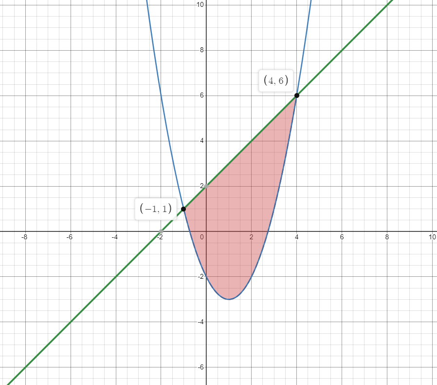

## Solution

Let $f(x) = x^2-2x-2$ and $g(x)=x+2$,

$$\int_{-1}^{4} f(x) - g(x) dx = \int_{1}^4 x^2-2x-2 - (x +2) dx =
\int_{1}^4 x^2 -3x - 4 dx \\
\Rightarrow \frac{x^3}{3} - \frac{x^2}{2} -4x |_{-1}^4 = [\frac{4^3}{3}
- \frac{4^2}{2} -4(4)] - [ \frac{-1^3}{3} - \frac{-1^2}{2} -4(-1)] \\
\Rightarrow -20.83$$

```r
integrand <- function(x) {
    x^2 - 3 * x - 4
}
integrate(integrand, -1, 4)
```

```
## -20.83333 with absolute error < 2.3e-13
```

# Exercise 5

A beauty supply store expects to sell 110 flat irons during the next year. It costs $3.75 to store one flat iron for one year. There is a fixed cost of $8.25 for each order. Find the lot size and the number of orders per year that will minimize inventory costs.

## Solution

First, we define the our variables

- TC = Total Cost
- Q = Quantity
- HC = Holding Cost = 3.75
- OC = Ordering Cost = 8.25
- D = Demand = 110

We have the following function

$$TC(Q) = \frac{D*OC}{Q} + \frac{HC*Q}{2}$$
To minimize, we will need to the derivative and solve for Q.

$$\frac{d}{dQ} TC = - \frac{D*OC}{Q^2} + \frac{HC}{2} = 0 \\
\Rightarrow \frac{HC}{2} = \frac{D*OC}{Q^2} \\
\Rightarrow Q^2 = \frac{2*D*OC}{HC} \\
\Rightarrow Q = \sqrt{\frac{2*D*OC}{HC}} \\
\Rightarrow Q = \sqrt{\frac{2*110*8.25}{3.75}} = 22$$

Which gives us the formula for the Economic Ordering Quantity in Economics.

Order per year = Demand / Q

$$Orders = 110 / 22 = 5$$

# Exercise 6

Use Integration by Parts to solve the integral below
$$\int ln(9x)x^6 dx$$

## Solution

$$\begin{align}
u = ln(9x), &\ dv = x^6 dx \\
du = \frac{1}{x}, &\ v = \frac{1}{7}x^7
\end{align}$$
$$ln(9x) \frac{1}{7}x^7 - \int \frac{1}{7}x^7 \frac{1}{x} \\
\Rightarrow \frac{x^7 ln(9x)}{7} - \frac{1}{7} \int x^6 dx \\
\Rightarrow \frac{x^7 ln(9x)}{7} - \frac{1}{7}(\frac{x^7}{7} + C) \\
\Rightarrow \frac{x^7 ln(9x)}{7} - \frac{x^7}{49} + C)$$

# Exercise 7

Determine whether f(x) is a probability density function on the interval $[1, e^6]$ . If not, determine the value of the definite integral. $f ( x ) = \frac{1}{6x}$

## Solution

$$\int_1^{e^6} \frac{1}{6x} dx = \frac{1}{6} \int_1^{e^6} \frac{1}{x} dx
\\
\Rightarrow \frac{1}{6} ln(x)|_1^{e^6} \\
\Rightarrow \frac{1}{6}[ln(e^6) - ln(1)] \\
\Rightarrow \frac{1}{6}[6 - 0] \\
= 1$$

So, since f(x) = 1 on the interval, this is a pdf.